# Détection de fraudes dans les cartes bancaires

# Problematique:

L'objectif de ce projet est la classification desequilibree des donnees, Ce déséquilibre de classe augmente nettement la difficulté de l’apprentissage par l’algorithme de classification. En effet, l’algorithme n’a que peu d’exemples de la classe minoritaire sur lesquels apprendre. Il est donc biaisé vers la population des négatifs et produit des prédictions potentiellement moins robustes qu’en l’absence de déséquilibre.

# Chargement des données

```
  Time         V1          V2        V3         V4          V5          V6
1    0 -1.3598071 -0.07278117 2.5363467  1.3781552 -0.33832077  0.46238778
2    0  1.1918571  0.26615071 0.1664801  0.4481541  0.06001765 -0.08236081
3    1 -1.3583541 -1.34016307 1.7732093  0.3797796 -0.50319813  1.80049938
4    1 -0.9662717 -0.18522601 1.7929933 -0.8632913 -0.01030888  1.24720317
5    2 -1.1582331  0.87773676 1.5487178  0.4030339 -0.40719338  0.09592146
6    2 -0.4259659  0.96052304 1.1411093 -0.1682521  0.42098688 -0.02972755
           V7          V8         V9         V10        V11         V12
1  0.23959855  0.09869790  0.3637870  0.09079417 -0.5515995 -0.61780086
2 -0.07880298  0.08510165 -0.2554251 -0.16697441  1.6127267  1.06523531
3  0.79146096  0.24767579 -1.5146543  0.20764287  0.6245015  0.06608369
4  0.23760894  0.37743587 -1.3870241 -0.05495192 -0.2264873  0.17822823
5  0.59294075 -0.27053268  0.8177393  0.75307443 -0.8228429  0.53819555
6  0.47620095  0.26031433 -0.5686714 -0.37140720  1.3412620  0.35989384
         V13        V14        V15        V16         V17         V18
```

[output cut: 20 more lines]

On commence d'abord par faire une bref description de notre base de données, celle ci est constitué 284807 transactions bancaires.

Il y a dans cette base de données 31 variables dont 28 provenant d’une transformation PCA (analyse en composantes principales) car malheureusement les caractéristiques premières contiennent des données confidentielles qui ne peuvent pas être fournies. Ces variables sont les colonnes V1, V2, ..., jusqu’à V28. Ces données sont par exemple le numéro de compte, les adresses de domicile, les dates d’expiration de cartes bleues, etc, ...

Les seules données qui n’ont pas été transformées sont les colonnes `Time`, `Amount` et `Class`:

- `Time` contient le temps écoulé entre chaque transaction et la première transaction de la base de données.
- `Amount` quant à lui contient les montants des transactions et cette caractéristique peut être utile pour reconnaître la sensibilité et l’importance des coûts des transactions.
- `Class` est la dernière variable qui vaut 1 si la transaction est une fraude et 0 sinon.

### Quelques statistiques pour chaque variables :

valeur minimale, premier quartile, médiane, moyenne, troisième quartile, valeur maximale

```
      Time              V1                  V2                  V3
 Min.   :     0   Min.   :-56.40751   Min.   :-72.71573   Min.   :-48.3256
 1st Qu.: 54202   1st Qu.: -0.92037   1st Qu.: -0.59855   1st Qu.: -0.8904
 Median : 84692   Median :  0.01811   Median :  0.06549   Median :  0.1799
 Mean   : 94814   Mean   :  0.00000   Mean   :  0.00000   Mean   :  0.0000
 3rd Qu.:139321   3rd Qu.:  1.31564   3rd Qu.:  0.80372   3rd Qu.:  1.0272
 Max.   :172792   Max.   :  2.45493   Max.   : 22.05773   Max.   :  9.3826
       V4                 V5                   V6                 V7
 Min.   :-5.68317   Min.   :-113.74331   Min.   :-26.1605   Min.   :-43.5572
 1st Qu.:-0.84864   1st Qu.:  -0.69160   1st Qu.: -0.7683   1st Qu.: -0.5541
 Median :-0.01985   Median :  -0.05434   Median : -0.2742   Median :  0.0401
 Mean   : 0.00000   Mean   :   0.00000   Mean   :  0.0000   Mean   :  0.0000
 3rd Qu.: 0.74334   3rd Qu.:   0.61193   3rd Qu.:  0.3986   3rd Qu.:  0.5704
 Max.   :16.87534   Max.   :  34.80167   Max.   : 73.3016   Max.   :120.5895
       V8                  V9                 V10                 V11
 Min.   :-73.21672   Min.   :-13.43407   Min.   :-24.58826   Min.   :-4.79747
 1st Qu.: -0.20863   1st Qu.: -0.64310   1st Qu.: -0.53543   1st Qu.:-0.76249
 Median :  0.02236   Median : -0.05143   Median : -0.09292   Median :-0.03276
 Mean   :  0.00000   Mean   :  0.00000   Mean   :  0.00000   Mean   : 0.00000
 3rd Qu.:  0.32735   3rd Qu.:  0.59714   3rd Qu.:  0.45392   3rd Qu.: 0.73959
 Max.   : 20.00721   Max.   : 15.59500   Max.   : 23.74514   Max.   :12.01891
      V12                V13                V14                V15
 Min.   :-18.6837   Min.   :-5.79188   Min.   :-19.2143   Min.   :-4.49894
 1st Qu.: -0.4056   1st Qu.:-0.64854   1st Qu.: -0.4256   1st Qu.:-0.58288
 Median :  0.1400   Median :-0.01357   Median :  0.0506   Median : 0.04807
 Mean   :  0.0000   Mean   : 0.00000   Mean   :  0.0000   Mean   : 0.00000
 3rd Qu.:  0.6182   3rd Qu.: 0.66251   3rd Qu.:  0.4931   3rd Qu.: 0.64882
 Max.   :  7.8484   Max.   : 7.12688   Max.   : 10.5268   Max.   : 8.87774
      V16                 V17                 V18
 Min.   :-14.12985   Min.   :-25.16280   Min.   :-9.498746
 1st Qu.: -0.46804   1st Qu.: -0.48375   1st Qu.:-0.498850
 Median :  0.06641   Median : -0.06568   Median :-0.003636
 Mean   :  0.00000   Mean   :  0.00000   Mean   : 0.000000
 3rd Qu.:  0.52330   3rd Qu.:  0.39968   3rd Qu.: 0.500807
 Max.   : 17.31511   Max.   :  9.25353   Max.   : 5.041069
      V19                 V20                 V21
 Min.   :-7.213527   Min.   :-54.49772   Min.   :-34.83038
 1st Qu.:-0.456299   1st Qu.: -0.21172   1st Qu.: -0.22839
 Median : 0.003735   Median : -0.06248   Median : -0.02945
 Mean   : 0.000000   Mean   :  0.00000   Mean   :  0.00000
```

[output cut: 8 more lines]

```
 Max.   : 10.503090   Max.   : 22.52841   Max.   : 4.58455
      V25                 V26                V27
 Min.   :-10.29540   Min.   :-2.60455   Min.   :-22.565679
 1st Qu.: -0.31715   1st Qu.:-0.32698   1st Qu.: -0.070840
 Median :  0.01659   Median :-0.05214   Median :  0.001342
 Mean   :  0.00000   Mean   : 0.00000   Mean   :  0.000000
 3rd Qu.:  0.35072   3rd Qu.: 0.24095   3rd Qu.:  0.091045
 Max.   :  7.51959   Max.   : 3.51735   Max.   : 31.612198
      V28                Amount             Class
 Min.   :-15.43008   Min.   :    0.00   Min.   :0.000000
 1st Qu.: -0.05296   1st Qu.:    5.60   1st Qu.:0.000000
 Median :  0.01124   Median :   22.00   Median :0.000000
 Mean   :  0.00000   Mean   :   88.35   Mean   :0.001728
 3rd Qu.:  0.07828   3rd Qu.:   77.17   3rd Qu.:0.000000
 Max.   : 33.84781   Max.   :25691.16   Max.   :1.000000
```

```
[1] "Occurence des fraudes"
```

```
     0      1
284315    492
```

## Analyse statistique des données

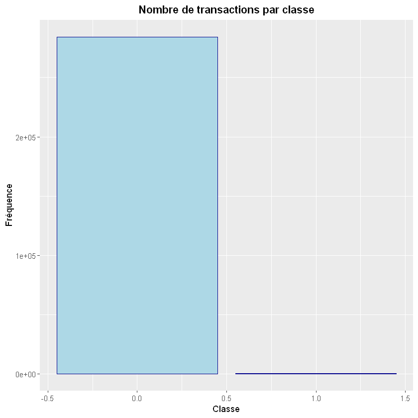

Dans notre cas, la classification déséquilibrée est un problème de classification dans lequel une classe est sous-représentée par rapport aux autres. Le cas classique est un problème à deux classes, une majoritaire à 99% et une minoritaire à 1%.

### Montants des transactions par classe

A tibble: 2 × 4

| Fraud <int> | mean(Amount) <dbl> | median(Amount) <dbl> | sd(Amount) <dbl> |
| --- | --- | --- | --- |
| 0 | 88.29102 | 22.00 | 250.1051 |
| 1 | 122.21132 | 9.25 | 256.6833 |

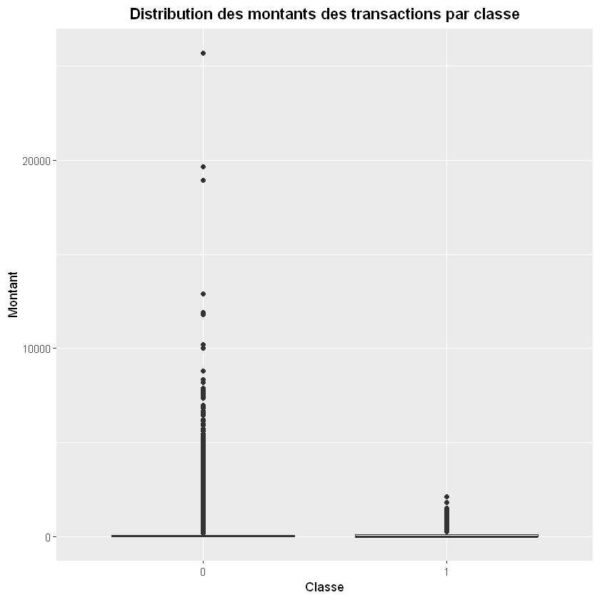

Pour les montants, On remarque que la medianne des transaction frauduleuse est plus faible. Cela est du au fait que lors d’une operation, c’est mieux d’effecetuer plusiers transactions de faible montant afin de ne pas etre ditinguer

### Densite en fonction du temps

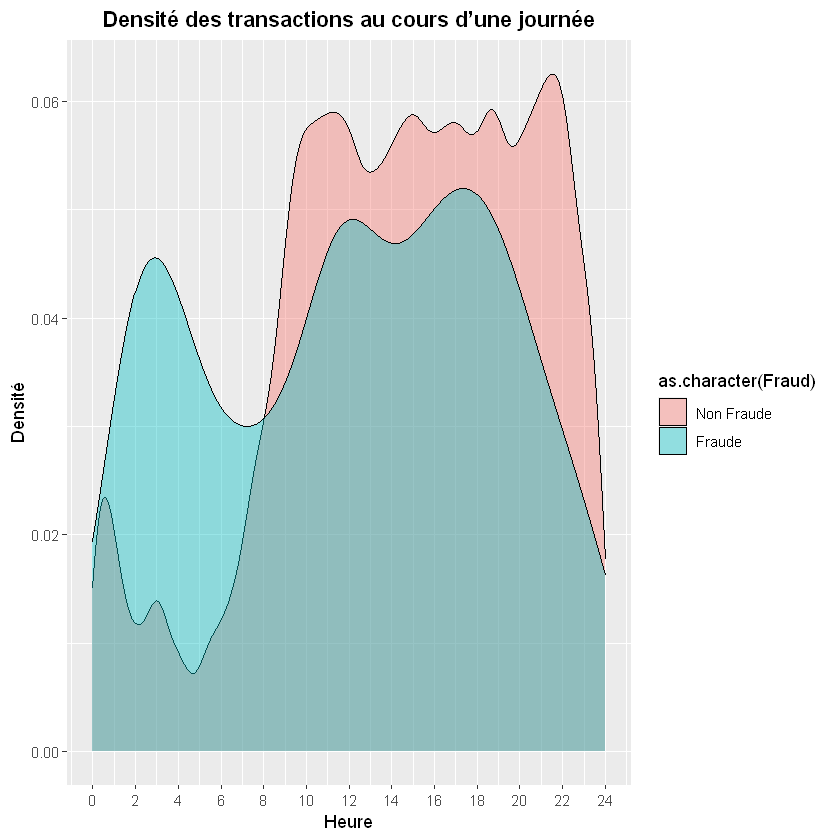

Concernant le temps des transactions, on remarque que les operations frauduleuses connaisent un pic en plein nuit, avec une densite beacuoup plus importante que cellles legitimes.

### Matrice de corrélation

Pour le prétraitement des données, nous avons vérifié qu’il n’existe pas de variables avec des données manquantes ou bien s’il y’a des données ‘NA’. Il n’y a donc pas de données manquantes dans notre base de données, et toutes nos entrées sont donc utiles pour entamer la suite.

Puis, comme on l’a mentionné auparavant, la base de donnée disponible sur Kaggle est le résultat d’une analyse en composantes principales, donc a priori on a pas besoin d’encore prétraiter ces données. Mais étant donné que la majorité des variables sont anonymisées pour des raisons confidentielles, nous avons voulu quand même vérifier s’il existe une corrélation entre elles.

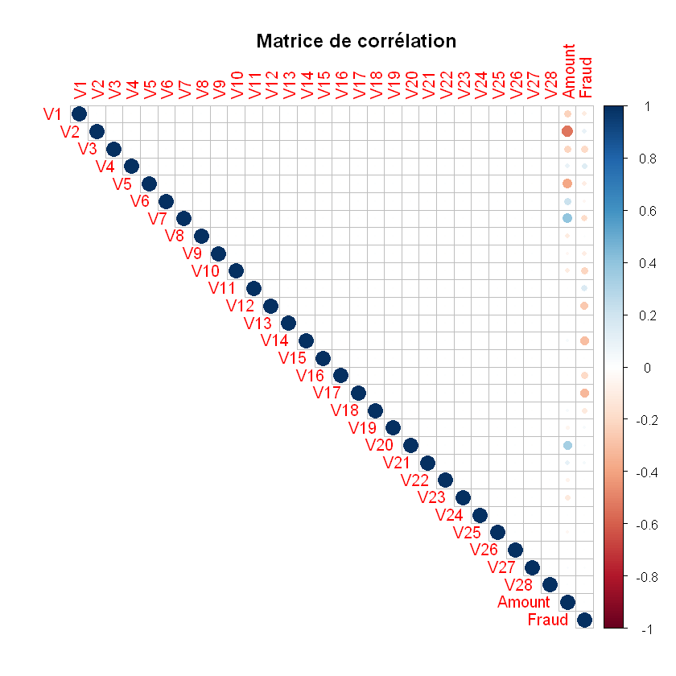

# Modeles de régression logistique

[figure not shown]

L'algorithme de régression logistique va mesurer la relation entre le "Label" Y et les "Caractéristiques" X en estimant les probabilités à l'aide d'une fonction logistique appelée fonction sigmoid. C’est la fonction représentée sur la première figure et qui a pour but de séparer les transactions frauduleuses de celles non frauduleuses.

On travaillera tout d'abord sur l'integralite de nos donnees.

Dans tous les modeles suivants, On va séparer notre jeu de données données en 2 groupes : un groupe de training et un groupe de test. et on effectue la regression avec un seuil de décision à 0.5.

### 1) Integralite des donnees

Extraction des données et division en deux jeux de données :

Nombre d'occurences du training set

```
     0      1
181953    323
```

Modele de regression logistique

```
Confusion Matrix and Statistics

          Reference
Prediction     0     1
         0 45483    33
         1     6    47

               Accuracy : 0.9991
                 95% CI : (0.9988, 0.9994)
    No Information Rate : 0.9982
    P-Value [Acc > NIR] : 2.756e-07

                  Kappa : 0.7064

 Mcnemar's Test P-Value : 3.136e-05

            Sensitivity : 0.587500
            Specificity : 0.999868
         Pos Pred Value : 0.886792
         Neg Pred Value : 0.999275
             Prevalence : 0.001756
         Detection Rate : 0.001031
   Detection Prevalence : 0.001163
      Balanced Accuracy : 0.793684

       'Positive' Class : 1
```

On remarque que l'accuracy de notre modele est de 99,9%. A premiere vue, le modele semble efficace mais dans le cas du déséquilibre de classes, l’exactitude peut être trompeuse. Avec un jeu de données de deux classes, où la première classe représente 99% des données, si le classifieur prédit que chaque exemple appartient à la première classe, l’exactitude sera de 99%, mais ce classifieur est inutile dans la pratique

### 2) UpSampling avec duplication

L'upsampling ou le sur-échantillonnage aléatoire consiste à compléter les données de formation par des copies multiples de certaines d’instances de la classe minoritaire.

```
[1] "Occurence des fraudes"
```

```
     0      1
284315 284315
```

On voit bien que nos donnes sont devenus equilibires apres avoir ajoute plusieurs copies des transactions frauduleuses.

On effectue alors la regression logistique

Extraction des données et division en deux jeux de données :

Modele de regression logistique

```
Confusion Matrix and Statistics

          Reference
Prediction     0     1
         0 44547  3594
         1   943 41896

               Accuracy : 0.9501
                 95% CI : (0.9487, 0.9515)
    No Information Rate : 0.5
    P-Value [Acc > NIR] : < 2.2e-16

                  Kappa : 0.9003

 Mcnemar's Test P-Value : < 2.2e-16

            Sensitivity : 0.9210
            Specificity : 0.9793
         Pos Pred Value : 0.9780
         Neg Pred Value : 0.9253
             Prevalence : 0.5000
         Detection Rate : 0.4605
   Detection Prevalence : 0.4709
      Balanced Accuracy : 0.9501

       'Positive' Class : 1
```

On obtient une *balanced accuracy* de 95% , mais avec cette methode on risque d'avoir un overfitting pour les transactions frauduleuses.

### 3)Upsamling with SMOTE method

Pour dépasser l'inconvénient imposé par un upsamling normal, la méthode Smote (Synthetic Minority Oversampling Technique) peut être utilisé. L’idée de SMOTE est d’augmenter le rappel pour la classe minoritaire en générant des individus synthétiques sur les segments entre éléments proches de la classe minoritaire.

[figure not shown]

```
[1] "Occurence des fraudes"
```

```
     0      1
283884 284376
```

On voit bien qu'on a generer autant de transactions frauduleuse que celles non frauduleuses.

Extraction des données et division en deux jeux de données :

Modele de regression

```
Confusion Matrix and Statistics

          Reference
Prediction     0     1
         0 44378  3406
         1  1040 42096

               Accuracy : 0.9511
                 95% CI : (0.9497, 0.9525)
    No Information Rate : 0.5005
    P-Value [Acc > NIR] : < 2.2e-16

                  Kappa : 0.9022

 Mcnemar's Test P-Value : < 2.2e-16

            Sensitivity : 0.9251
            Specificity : 0.9771
         Pos Pred Value : 0.9759
         Neg Pred Value : 0.9287
             Prevalence : 0.5005
         Detection Rate : 0.4630
   Detection Prevalence : 0.4744
      Balanced Accuracy : 0.9511

       'Positive' Class : 1
```

Le modele de regression est devenu plus efficace avec une balanced accuracy de 95,11%.

### 4) Regression logistique pondérée

Dans la plupart des modeles de Machine learning, ils acceptent un parametre `weight`. Il sert à appliquer un coût inversement proportionnel au déséquilibre de classe. Visuellement, cela permet de débiaiser le modèle vers la classe minoritaire comme illustré ci-dessous où la frontière de décision d’un SVM à noyau linéaire est translatée vers la classe minoritaire.

[figure not shown]

Dans notre cas, on prend notre poids comme suite: $$ \text{weight}= \frac{\sum(\text{non frauduleuses)}}{\sum(\text{frauduleuses)}} $$

```
weight= 577
somme des poids: 568199
```

Extraction des données et division en deux jeux de données :

Modele de regression logistique ponderée

```
Confusion Matrix and Statistics

          Reference
Prediction     0     1
         0 45490     0
         1     0    78

               Accuracy : 1
                 95% CI : (0.9999, 1)
    No Information Rate : 0.9983
    P-Value [Acc > NIR] : < 2.2e-16

                  Kappa : 1

 Mcnemar's Test P-Value : NA

            Sensitivity : 1.000000
            Specificity : 1.000000
         Pos Pred Value : 1.000000
         Neg Pred Value : 1.000000
             Prevalence : 0.001712
         Detection Rate : 0.001712
   Detection Prevalence : 0.001712
      Balanced Accuracy : 1.000000

       'Positive' Class : 1
```

Apres entrainenment, on voit qu’on a obtenu une précision de 100%, la méthode de régression logistique pondérée est efficace et plus adaptée a notre problème!